# merged_all_weeks

# Union-Find Data Structure

### Kruskal's Algorithm for Minimum Cost Spanning Tree (MCST)

- Process the edges in ascending order of cost
- If edge $(u, v)$ does not create a cycle, add it
  - $(u, v)$ can be added if $u$ and $v$ are in different components
  - Adding edge $(u, v)$ merges these components
- How can we keep track of components and merge them efficiently?
- Components **partition** vertices
  - Collection of disjoint sets
- Need data structure to maintain collection of disjoint sets
  - `find(v)` - return set containing `v`
  - `union(u, v)` - merge sets of `u, v`

### Union-Find Data Structure

- A set $S$ partitioned into components $\{C_1, C_2, ..., C_k\}$
  - Each $s \in S$ belongs to exactly one $C_j$
- Support the following operations
  - `MakeUnionFind(S)` - set up initial singleton components $\{s\}$, for each $s \in S$
  - `Find(s)` - return the components containing $s$
  - `Union(s, s')` - merges components containing `s, s'`

### Naive Implementation

- Assume $S = \{0, 1, ..., n - 1\}$
- Set up an array/dictionary `Component`
- `MakeUnionFind(S)`
  - Set `Component[i] = i` for each `i`
- `Find(i)`
  - Return `Component[i]`
- `Union(i, j)`

  ```
  c_old = Component[i]
  c_new = Component[j]

  for k in range(n):
    if Component[k] == c_old:
      Component[k] = c_new
  ```

**Complexity**

- `MakeUnionFind(S)` - $O(n)$
- `Find(i)` - $O(1)$
- `Union(i, j)` - $O(n)$
- Sequence of $m$ `Union()` operations takes time $O(mn)$

### Improved Implementation

- Another array/dictionary `Members`
- For each component $c$, `Members[c]` is a list of its members
- `Size[c] = length(Members[c])` is the number of members
- `MakeUnionFind(S)`
  - Set `Component[i] = i` for all `i`
  - Set `Members[i] = i, Size[i] = 1` for all `i`
- `Find(i)`
  - Return `Component[i]`
- `Union(i, j)`

  ```
  c_old = Component[i]
  c_new = Component[j]

  for k in Members[c_old]:
    Component[k] = c_new
    Members[c_new].append(k)
    Size[c_new] += 1
  ```

### Why does this help?

- `MakeUnionFind(S)`
  - Set `Component[i] = i` for all `i`
  - Set `Members[i] = [i], Size[i] = 1` for all `i`
- `Find(i)`
  - Return `Component[i]`
- `Union(i, j)`

  ```
  c_old = Component[i]
  c_new = Component[j]

  for k in Members[c_old]:
    Component[k] = c_new
    Members[c_new].append(k)
    Size[c_new] += 1
  ```

- `Members[c_old]` allows us to merge `Component[i]` into `Component[j]` in time $O(Size[c\_old])$ rather than $O(n)$
- How can we make use of `Size[c]`
  - Always merge smaller component into the larger one
  - If `Size[c] < Size[c']` re-label `c` as `c'`, else re-label `c'` as `c`
- Individual merge operatios can still take time $O(n)$
  - Both `Size[c], Size[c']` could be about $n/2$
  - More careful accounting
- Always merge smaller component into the larger one
- For each `i`, size of `Component[i]` at least doubles each time it is re-labelled
- After $m$ `Union()` operations, at most $2m$ elements have been "touched"
  - Size of `Component[i]` is at most $2m$
- Size of `Component[i]` grows as $1, 2, 4, ...,$ so `i` changes component at most $log \ m$ times
- Over $m$ updates
  - At most $2m$ updates are re-labelled
  - Each one at most $O(log \ m)$ times
- Overall, $m$ `Union()` operations take time $O(m.log \ m)$
- Works out to time $O(log \ m)$ per `Union()` operation
  - Amortized complexity of `Union()` is $O(log \ m)$

### Back to Kruskal's Algorithm

- Sort $E = \{e_0, e_1, ..., e_{m - 1}\}$ in ascending order
- `MakeUnionFind(V)` - each vertex `j` is in component `j`
- Adding an edge $e_k = (u, v)$ to the tree
  - Check that `Find(u) != Find(v)`
  - Merge components: `Union(Component[u], Component[v])`
- Tree has $n - 1$ edges, so $O(n)$ `Union()` operations
  - $O(n.logn)$ amortized cost overall
- Sorting $E$ takes $O(m.logm)$
  - Equivalently, $O(m.logm)$, since $m \leq n^2$
- Overall time, $O((m + n)logn)$

### Summary

- Implement Union-Find using arrays/dictionaries `Component, Member, Size`
  - `MakeUnionFind(S)` is $O(n)$
  - `Find(i)` is $O(1)$
  - Across $m$ operations, amortized complexity of each `Union()` operation is $log \ m$
- Can also maintain `Members[k]` as a tree rather than as a list
  - `Union()` becomes $O(1)$

# Priority Queues

### Dealing with Priorities

**Job Scheduler**

- A job scheduler maintains a list of pending jobs with their priorities
- When the processor is free, the scheduler picks out the job with maximum priority in the list and schedules it
- New jobs may join the list at any time
- How should the scheduler maintain the list of pending jobs and their priorities?

**Priority Queue**

- Need to maintain a collection of items with priorities to optimize the following operations
- `delete_max()`
  - Identify and remove item with the highest priority
  - Need not be unique
- `insert()`
  - Add a new item to the collection

### Implementing Priority Queues with one dimensional structures

- `delete_max()`
  - Identify and remove item with highest priority
  - Need not be unique
- `insert()`
  - Add a new item to the list
- Unsorted list
  - `insert()` is $O(1)$
  - `delete_max()` is $O(n)$
- Sorted list
  - `delete_max()` is $O(1)$
  - `insert()` is $O(n)$
- Processing $n$ items requires $O(n^2)$

### Moving to 2 dimensions

**First Attempt**

- Assume $N$ processes enter/leave the queue
- Maintain a $\sqrt{N} \times \sqrt{N}$ array
- Each row is in sorted order

N = 25

| 3 | 19 | 23 | 35 | 58 |
| --- | --- | --- | --- | --- |
| 12 | 17 | 25 | 43 | 67 |
| 10 | 13 | 20 |  |  |
| 11 | 16 | 28 | 49 |  |
| 6 | 14 |  |  |  |

### Summary

- 2D $\sqrt{N} \times \sqrt{N}$ array with sorted rows
  - `insert()` is $O(\sqrt{N})$
  - `delete_max()` is $O(\sqrt{N})$
  - Processing $N$ items is $O(N \sqrt{N})$
- Can we do better than this?
- Maintain a special binary tree - **heap**
  - Height $O(log \ N)$
  - `insert()` is $O(log \ N)$
  - `delete_max()` is $O(log \ N)$
  - Processing $N$ items is $O(N.log \ N)$
- Flexible - need not fix $N$ in advance

# Heaps

### Priority Queue

- Need to maintain a collection of items with priorities to optimize the following operations
- `delete_max()`
  - Identify and remove item with highest priority
  - Need not be unique
- `insert()`
  - Add a new item to the list
- Maintaining as a list incurs cost $O(N^2)$ across $N$ inserts and deletions
- Using a $\sqrt{N} \times \sqrt{N}$ array reduces the cost to $O(\sqrt{N})$ per oprations
  - $O(N \sqrt{N})$ across $N$ inserts and deletions

### Binary Trees

- Values are stored as nodes in a rooted tree
- Each node has up to two children
  - Left child and Right child
  - Order is important
- Other than the root, each node has a unique parent
- Leaf node - no children
- Size - number of nodes
- Height - number of levels

[figure not shown]

### Heap

- Binary tree filled level-by-level, left-to-right
- The value at each node is at least as big as the values of its children
  - **max-heap**
- Binary tree on the right is an example of a heap
- Root always has the largest value
  - By induction, because of the **max-heap** property

[figure not shown]

### Non-Examples

[figure not shown]

### Complexity of `insert()`

- Need to walk up from the leaf to the root
  - Height of the tree
- Number of nodes at level $0$ is $2^0 = 1$
- If we fill $k$ levels, $2^0 + 2^1 + ... + 2^{k - 1} = 2^k - 1$ nodes
- If we have $N$ nodes, at most $1 + log \ N$ levels
- `insert()` is $O(log \ N)$

### `delete_max()`

- Maximum value is always at the root
- After we delete one value, tree shrinks
  - Node to delete is right-most at lowest level
- Move "homeless" value to the root
- Restore the heap property downwards
- Only need to follow a single path down
  - Again $O(log \ N)$

### Implementation

- Number the nodes top to bottom left right
- Store as a list `H = [h0, h1, h2, ..., h9]`
- Children of `H[i]` are at `H[2 * i + 1], H[w * i + 2]`
- Parent of `H[i]` is at `H[(i - 1)//2]`, for `i > 0`

### Building a heap - `heapify()`

- Convert a list `[v0, v1, ..., vN]` into a heap
- Simple strategy
  - Start with an empty heap
  - Repeatedly apply `insert(vj)`
  - Total time is $O(N.log \ N)$

### Better `heapify()`

- List `L = [v0, v1, ..., vN]`
- `mid = len(L)//2`, Slice `L[mid:]` has only leaf nodes
  - Already satisfy the heap condition
- Fix heap property downwards for second last level
- Fix heap property downwards for third last level
- ...
- Fix heap property at level 1
- Fix heap property at the root
- Each time we go up one level, one extra step per node to fix the heap peoperty
- However, number of nodes to fix halves
- Second last level, $n/4 \times 1$ steps
- Third last level, $n/8 \times 2$ steps
- Fourth last level, $n/16 \times 3$ steps
- ...
- Cost turns out to be $O(n)$

### Summary

- Heaps are a tree implementation of priority queues
  - `insert()` is $O(log \ N)$
  - `delete_max()` is $O(log \ N)$
  - `heapify()` builds a heap in $O(N)$
- Can invert the heap condition
  - Each node is smaller than its children
  - **min-heap**
  - `delete_min()` rather than `delete_max()`

# Using Heaps in Algorithms

### Priority Queues and Heaps

- Priority Queues support the following operations
  - `insert()`
  - `delete_max()` or `delete_min()`
- Heaps are tree based implementation of priority queues
  - `insert(), delete_max()/delete_min()` are both $O(log \ n)$
  - `heapify()` builds a heap from a list/array in time $O(n)$
- Heap can be represented as a list/array
  - Simple index arithmetic to find parent and children of a node
- What more do we need to use a heap in an algorithm?

### Dijkstra's Algorithm

- Maintain 2 dictionaries with vertices as keys
  - `visited`, initially `False` for all `v`
  - `distance`, initially `infinity` for all `v`
- Set `distance[v]` to $0$
- Repeat, untill all the reachable vertices are visited
  - Find unvisited vertex `nextv` with minimum distance
  - Set `visited[nextv]` to `True`
  - Re-compute `distance[v]` for every neighbour `v` of `nextv`

```python
def dijkstra(WMat,s):
  (rows,cols,x) = WMat.shape
  infinity = np.max(WMat)*rows+1
  (visited,distance) = ({},{})

  for v in range(rows):
    (visited[v],distance[v]) = (False,infinity)

  distance[s] = 0

  for u in range(rows):
    nextd = min([distance[v] for v in range(rows)
                    if not visited[v]])
    nextvlist = [v for v in range(rows)
                    if (not visited[v]) and distance[v] == nextd]

  if nextvlist == []:
    break

  nextv = min(nextvlist)
  visited[nextv] = True

  for v in range(cols):
    if WMat[nextv,v,0] == 1 and (not visited[v]):
      distance[v] = min(distance[v],distance[nextv] + WMat[nextv,v,1])

  return distance
```

**Bottleneck**

- Find unvisited vertex $j$ with minimum distance
  - Naive implementation requires an $O(n)$ scan
- Maintain unvisited vertices as a min-heap
  - `delete_min()`in $O(log \ n)$ time
- But, also need to update distances of the neighbours
  - Unvisited neighbour's distances are inside the min-heap
  - Updating a value is not a basic heap operation

### Heap sort

- Start with an un-ordered list
- Build a heap - $O(n)$
- Call `delete_max()` $n$ times to extract elements in descending order - $O(n.log \ n)$
- After each `delete_max()`, heap shrinks by 1
- Store maximum value at the end of current heap
- In place $O(n.log \ n)$ sort

### Summary

- Updating a value in a heap takes $O(log \ n)$
- Need to maintain additional pointers to map values to heap positions and vice versa
- With this extended notion of heap, Dijkstra’s algorithm complexity improves from $O(n^2)$ to $O((m + n).log \ n)$
- Heaps can also be used to sort a list in place in $O(n.log \ n)$

# Search Trees

### Dynamic Sorted Data

- Sorting is useful for efficient searching
- What if the data is changing dynamically?
  - Items are periodically inserted and deleted
- Insert/delete in a sorted list takes time $O(n)$
- Move to a tree structure, like heaps for priority queues

### Binary Search Tree

- For each node with the value $v$
  - All values in the left sub-tree are $\lt v$
  - All values in the right sub-tree are $\gt v$
- No duplicate values

[figure not shown]

### Implementing a Binary Search Tree

- Each node has a value and pointers to its children
- Add a frontier with empty nodes, all fields -
  - Empty tree is single empty node
  - Leaf node points to empty nodes
- Easier to implement operations recursively

### The class `Tree`

- Three local fields `value`, `'left`, 'right'
- Value `None` for empty value
- Empty tree has all fields `None`
- Left has a non-empty `value` and empty `left` and `right`

```python
class Tree:
  # Constructor
  def __init__(self, init_val = None):
    self.value = init_val

    if self.value:
      self.left = Tree()
      self.right = Tree()
    else:
      self.left = None
      Self.right = None

    return

  # Only empty node has value None
  def is_empty(self):
    return self.value == None

  # Leaf nodes have both children empty
  def is_leaf(self):
    return self.value != None and self.left.is_empty() and self.right.is_empty()
```

### In-order traversal

- List the left sub-tree, then the current node, then the right sub-tree
- Lists values in sorted order
- Use to print the tree

```python
class Tree:
  ...
  # In-order traversal
  def in_order(self):
    if self.is_empty():
      return []
    else:
      return self.left.in_order() + [self.value] + self.right.in_order()

  # Display the tree as a string
  def __str__(self):
    return str(self.in_order())
```

### Find a value `v`

- Check value at current node
- If `v` is smaller than the current node, go left
- If `v` is greater than the current node, go right
- Natural generalization of binary search

```python
class Tree:
  ...
  # Check if the value v occurs in the tree
  def find(self, v):
    if self.is_empty():
      return False

    if self.value == v:
      return True

    if v < self.value:
      return self.left.find(v)

    if v > self.value:
      return self.right.find(v)
```

### Minimum and Maximum

- Minimum is the left most node in the tree
- Maximum is the right most node in the tree

```python
class Tree:
  ...
  def min_val(self):
    if self.left.is_empty():
      return self.value
    else:
      return self.left.min_val()

  def max_val(self):
    if self.right.is_empty():
      return self.value
    else:
      return self.right.max_val()
```

### Insert a value `v`

- Try to find `v`
- Insert at the position where `find` fails

```python
class Tree:
  ...
  def insert(self, v):
    if self.is_empty():
      self.value = v
      self.left = Tree()
      self.right = Tree()

    if self.value == v:
      return

    if v < self.value:
      self.left.insert(v)
      return

    if v > self.value:
      self.right.insert(v)
      return
```

### Delete a value `v`

- If `v` is present, delete
- Leaf node? No problem
- If only one child, promote that sub-tree
- Otherwise, replace `v` with `self.left.max_val()` and delete `self.left.max_val()`
  - `self.left.max_val()` has no right child

```python
class Tree:
  ...
  def delete(self, v):
    if self.is_empty():
      return

    if v < self.value:
      self.left.delete(v)
      return

    if v > self.value:
      self.right.delete(v)
      return

    if v == self.value:
      if self.is_leaf():
        self.make_empty()
      elif self.left.is_empty():
        self.copy_right()
      elif self.right.is_empty():
        self.copy_left()
      else:
        self.value = self.left.max_val()
        self.left.delete(self.left.max_val())
      return

  # Convert left node to empty node
  def make_empty(self):
    self.value = None
    self.left = None
    self.right = None
    return

  # Promote left child
  def copy_left(self):
    self.value = self.left.value
    self.right = self.left.right
    self.left = self.left.left
    return

  # Promote right child
  def copy_right(self):
    self.value = self.right.value
    self.left = self.right.left
    self.right = self.right.right
    return
```

### Summary

- `find(), insert() and delete()` all walk down a single path
- Worst-case: height of the tree
- An un-balanced tree with $n$ nodes may have the height $O(n)$
- Balanced trees have height $O(log \ n)$
- We will see how to keep a tree balanced to ensure all operations remain $O(log \ n)$

# Divide and Conquer: Counting Inversions

### Divide and Conquer

- Break the problem into disjoint sub-problems
- Combine these sub-problem solutions efficiently

**Examples**

- Merge sort
  - Split into left and right half and sort each half separately
  - Merge the sorted halves
- Quicksort
  - Re-arrange into lower and upper partitions, sort each partition separately
  - Place pivot between sorted lower and upper partitions

### Recommender systems

- Online services recommend items to you
- Compare your profile with other customers
- Identify people who share your likes and dislikes
- Recommend items that they like
- Comparing profiles: How similar are your rankings to those of others?

**Comparing rankings**

- You and your friend rank $5$ movies $\{A,B,C,D,E\}$
  - Your ranking: $D,B,C,A,E$
  - Your friend's ranking: $B,A,C,D,E$
- How to measure how similar these rankings are?
- For each pair of movies, compare preferences
  - You rank $B$ above $C$, so does your friend
  - You rank $D$ aboe $B$, your friend ranks $B$ above $D$

### Compare based on inversions

**Inversions**

- Pair of movies ranked in opposite order
  - You rank $D$ above $B$, your friend ranks $B$ above $D$
- No inversion $\implies$ rankings identical
- Every pair inverted $\implies$ maximally dissimilar
- Number of inversions range from $0$ to $n(n - 1)/2$ $\rightarrow$ measure of dissimilarity

**Permutations**

- Fix the order of one ranking as a sorted sequence $1, 2, ..., n$
- The other ranking is a permutation of $1, 2, ..., n$
- An inversion is a pair $(i, j), i \lt j$, where $j$ appears before $i$

### Counting inversions

- Number of inversions ranges from $0$ to $n(n - 1)/2$ $\rightarrow$ measure of dissimilarity
- Your ranking: D, B, C, A, E
  - D = 1, B = 2, C = 3, A = 4, E = 5
- Your friend's ranking: B, A, C, D, E
  - 2, 4, 3, 1, 5
- Inversions in 2, 4, 3, 1, 5?
- (1, 2), (1, 3), (1, 4), (3, 4)

**Graphically**

- Write the 2 permutations as 2 rows of nodes
- Connect every pair $(j, j)$ between the two rows

[figure not shown]

- Every crossing is an inversion
- Brute force - check every $(i, j), O(n^2)$

### Divide and Conquer

- Friend's permutation is $i_1, i_2, ..., i_n$
- Divide into 2 lists
  - $L = [i_1, i_2, ..., i_{n/2}]$
  - $R = [i_{n/2 + 1}, i_{n/2 + 2}, ..., i_{n}]$
- Recursively count inversions in $L$ and $R$
- Add inversions across the boundary between $L$ and $R$
  - $i \in L, j \in R, i \gt j$
  - How many elements in $L$ are bigger than elements in $R$?
- How to count inversions across the boundary?
- Adapt merge sort
- Recursively **sort and count** inversions in $L$ and $R$
- Count inversions while merging - **merge and count**

**Merge and Count**

- Merge $L = [i_1, i_2, ..., i_{n/2}]$ and $R = [i_{n/2 + 1}, i_{n/2 + 2}, ..., i_n]$, sorted
- Count inversions while merging
  - If we add $i_m$ from $R$ to the output, $i_m$ is smaller than elements currently in $L$
  - $i_m$ is hence inverted w.r.t. elements currently in $L$
  - Add current size (total size - current pointer index) of $L$ to the inversion count

```python
def merge_and_count(A, B):
  m = len(A)
  n = len(B)
  C = []
  i, j, k, count = 0, 0, 0, 0

  while k < m + n:
    if i == m:
      C.append(B[j])
      j += 1
      k += 1
    elif j == n:
      C.append(A[i])
      i += 1
      k += 1
    elif A[i] < B[j]:
      C.append(A[i])
      i += 1
      k += 1
    else:
      C.append(B[j])
      j += 1
      k += 1
      count = count + (m - i) # m - i is the current length of L

  return (C, count)
```

- `sort_and_count` is merge sort with `merge_and_count`

```python
def sort_and_count(A):
  n = len(A)
  if n <= 1:
    return (A, 0)

  (L, countL) = sort_and_count(A[:n//2])
  (R, countR) = sort_and_count(A[n//2:])
  (B, countB) = merge_and_count(L, R) # countB is cross inversions

  return (B, countL + countR + countB)
```

### Analysis

- Recurrence is similar to merge sort
  - $T(0) = T(1) = 1$
  - $T(n) = 2T(n/2) + n$
- Solve to get $T(n) = O(n \ log \ n)$
- Note that the number of inversions can still be $O(n^2)$
  - Number ranges from $0$ to $n(n - 1)/2$
- We are counting them efficiently without enumerating each one

# **Divide and Conquer: Closest pair of points**

### Recall: Video game

- Several objects on the screen
- Basic step: Find the closest pair of objects
- $n$ objects - naive algorithm is $n^2$
  - For each pair of objects, compute their distance
  - Report minimum distance across all pairs
- There is a clever algorithm that takes time $n \ log_2 \ n$
- Uses divide and conquer

### The problem statement

- Points $p$ in $2D$ - $p = (x, y)$
- Usual Euclidean distance between $p_1 = (x_1, y_1)$ and $p_2 = (x_2, y_2)$
  - $d(p_1, p_2) = \sqrt{(y_2 - y_1)^2 + (x_2 - x_1)^2}$
- Given $n$ points $p_1, p_2, ..., p_n$ find the closest pair
  - Assume no two points have same $x$ or $y$ coordinate
  - We can always rotate the points slightly to ensure this
  - or we can modify the algorithm slightly
- Brute force
  - Compute $d(p_i, p_j)$ for every pair of points
  - $O(n^2)$

### Finding the closest pair of points

**In 1 dimension**

- Given $n$ 1D points $x_1, x_2, ..., x_n$, find the closest pair
  - $d(p_i, p_j) = |x_j - x_i|$
- Sort the points - $O(n \ log \ n)$
- In sorted order, nearest points to $p$ are its neighbours
  - $O(n)$ scan to find the minimum separation between adjacent points

**In 2 dimensions**

- Divide and Conquer
- Split the points in 2 halves by a vertical line
- Recursively compute closest pair in each half
- Compare shortest distance in each half to shortest distance across the dividing line
- How to do this efficiently?

### Dividing Points

- Given $n$ points $P = \{p_1, p_2, ..., p_n\}$ compute
  - $P_x, P$ sorted by $x$-coordinate
  - $P_y, P$ sorted by $y$-coordinate
- Divide $P$ by a vertical line into equal size $Q, R$
- How to compute $Q_x, Q_y, R_x, R_y$ efficiently?
- $Q_x$ is the first half of $P_x, R_x$ is the second half of $P_x$
- Let $x_R$ be the smallest $x$ coordinate in $R$
- For $p \in P_y$, if $x$-coordinate of $p$ is less than $x_R$, move $p$ to $Q_y$, else $R_y$
- All of this can be done is $O(n)$

[figure not shown]

### Divide and Conquer

- Want to compute $ClosestPair(P_x, P_y)$
- Split $(P_x, P_y)$ as $(Q_x, Q_y), (R_x, R_x)$
- Recursively compute $ClosestPair(Q_x, Q_y)$ and $ClosestPair(R_x, R_y)$'
- How to combine these recursive solutions?

### Combining Solutions

- Let $d_Q, d_R$ be the closest distances in $Q, R$, respectively
- Set $\delta = min(d_Q, d_R)$
- Only need to consider points within distance $\delta$ on either side of the separator
- No pair outside this band can be closer than $\delta$

[figure not shown]

### Combining Solutions

- Divide the distance $\delta$ band into boxes of side $\delta / 2$
- We cannot have 2 points inside the same box
  - Box diagonal is $\delta / \sqrt{2}$
- Any point within the distance $\delta$ must lie in a $4 \times 4$ neighbourhood of boxes
  - Check each point against $15$ others
- From $Q_y, R_y$, extract $S_y$, points in $\delta$ band sorted by $y$
- Scan $S_y$ from bottom to top, comparing each $p$ with next $15$ points in $S_y$
- Linear scan

[figure not shown]

### Algorithm and Analysis

**Pseudocode**

```python
def ClosestPair(Px, Py):

  if len(Px) <= 3:
    compute pairwise distances
    return closest pair and distance

  Construct (Qx, Qy), (Rx, Ry)

  (q1, q2, dQ) = ClosestPair(Qx, Qy)
  (r1, r2, dR) = ClosestPair(Rx, Ry)

  Construct Sy from Qy, Ry
  Scan Sy, find (s1, s2, dS)

  return (q1, q2, dQ), (r1, r2, QR), (s1, s2, dS)
  depending on which of dQ, dR, dS is minimum
```

**Analysis**

- Sort $P$ to get $P_x, P_y$ - $O(n \ log \ n)$
- Recursive algorithm
  - Construct $(Q_x, Q_y), (R_x, R_y)$ - $O(n)$
  - Construct $S_y$ from $Q_y, R_y$ - $O(n)$
  - Scan $S_y$ - $O(n)$
- Recurrence: $T(n) = 2T(n/2) + O(n)$ like merge sort
- Overall, $O(n \ log \ n)$

# Divide and Conquer: Integer Multiplication

### Integer Multiplication

- How do we multiply two integers $x, y$?
- Form **partial products** - multiply each digit of $y$ separately by $x$
- Add up all the partial products
- Works the same in any base - e.g. Binary
- To multiply 2 $n$-bit numbers
  - $n$ partial products
  - Adding each partial product to cumulative sum is $O(n)$
  - Overall $O(n^2)$
- Can we improve on this?
  - Each partial product seems "necessary"

[figure not shown]

### Divide and Conquer

- Split the $n$ bits into 2 groups of $n/2$

[figure not shown]

- Rewrite $xy$ as $(x_1.2^{n/2} + x_0)(y_1.2^{n/2} + y_0)$
- Regroup as $x_1y_1.2^n + (x_1y_0 + x_0y_1).2^{n/2} + x_0y_0$
- Four $n/2$-bit multiplications
- $T(1) = 1, T(n) = 4T(n/2) + n$
  - Combining the partial products requires adding $O(n)$ bit numbers

[figure not shown]

### Karatsuba's algorithm

- Rewrite $xy$ as $x_1y_1.2^n + (x_1y_0 + x_0y_1).2^{n/2} + x_0y_0$
- $T(n) = 4T(n/2) + n$ is $O(n^2)$
- Divide and Conquer has not helped!
- $(x_1 - x_0)(y_1 - y_0) = x_1y_1 - x_1y_0 - x_0y_1 + x_0y_0$
  - $O(n/2)$ bit multiplication
- Compute $x_1y_1, x_0y_0$
  - $O(n/2)$ bit multiplications
- $(x_1y_1 + x_0y_0) - (x_1 - x_0)(y_1 - y_0)$ leaves $x_1y_0 + x_0y_1$
  - $3 \ O(n/2)$ bit multiplications

**The Algorithm**

[figure not shown]

### Karatsuba's algorithm - Analysis

[figure not shown]

### Historical note

# Divide and Conquer: Recursion Trees

### Solving recurrences

- Divide and conquer involves breaking up a problem into disjoint subproblems and combining the solutions efficiently
- Complexity $T(n)$ is expressed as a recurrence
- For searching and sorting, we solved simple recurrence by repeated substitution
  - Binary search: $T(n) = T(n/2) + 1, T(n)$ is $O(log \ n)$
  - Merge sort: $T(n) = 2T(n/2) + n, T(n)$ is $O(n \ log \ n)$
- For integer multiplication, the analysis became more complicated
  - Naive divide and conquer: $T(n) = 4T(n/2) + n, T(n)$ is $O(n^2)$
  - Karatsuba's algorithm: $T(n) = 3T(n/2) + n$ is $O(n^{log_{2}3})$
- Is there a uniform way to compute the asymptotic expression for $T(n)$?

### Recursion Trees

- **Recursion tree** Rooted tree with one node for each recursive subproblem
- **Value** of each node is time spent on that subproblem **excluding** recursive calls
- Concretely, on an input of size $n$
  - $f(n)$ is the time spent on non-recursive work
  - $r$ is the number of recursive calls
  - Each recursive call works on a subproblem of size $n/c$
- Resulting recurrence: $T(n) = rT(n/c) + f(n)$
- Root of recursion tree for $T(n)$ has value of $f(n)$
- Root has $r$ children, each (recursively) the root of a tree for $T(n/c)$
- Each node at level $d$ has value $f(n/c^d)$
  - Assume, for simplicity, that $n$ was a power of $c$

### Recursion tree for $T(n) = rT(n/c) + f(n)$

[figure not shown]

### Recursion Trees

- Leaves correspond to the base case $T(1)$
  - Safe to assume $T(1) = 1$, asymptotic complexity ignores constants
- Level $i$ has $r^i$ nodes, each with value $f(n/c^i)$
- Tree has $L$ levels, $L = log_c \ n$
- Total cost is $T(n) = \sum_{i = 0}^{L} r^i.f(n/c^i)$
- Number of leaves is $r^L$
  - Last term in the level by level sum is $r^L.f(1) = r^{log_c \ n}.1 = n^{log_c \ r}$
  - Recall that $a^{log_b \ c} = c^{log_b \ a}$
- Tree has $log_c \ n$ levels, last level has the cost $n^{log_c \ r}$
- Total cost is $T(n) = \sum_{i = 0}^{L} r^i.f(n/c^i)$
- Think of the total cost as a series. Three common cases
- **Decreasing** Each term is a constant factor smaller than the previous term
  - Root dominates the sum, $T(n) = O(f(n))$
- **Equal** All terms in the series are equal
  - $T(n) = O(f(n).L) = O(f(n) log \ n) - log_c \ n$ is asymptotically the same as $log \ n$
- **Increasing** Series grows exponentially, each term a constant factor larger than the previous term
  - Leaves dominate the sum, $T(n) = O(n^{log_c \ r})$

# Divide and Conquer: Quick Select

### Selection

- Find the $k^{th}$ largest value in a sequence of length $n$
- Sort in descending order and look at position $k$ - $O(n \ log \ n)$
- Can we do better than this?
  - $k = 1$ - maximum, $O(n)$
  - $k = n$ - minimum, $O(n)$
- For any fixed $k$, $k$ passes, $O(kn)$
- Median - $k = n / 2$
  - If we can find median $O(n)$, quicksort becomes $O(n \ log \ n)$

### Divide and Conquer

- Recall partitioning for quicksort
  - Pivot partitions sequence as `lower` and `upper`
- Let `m = len(lower)`. 3 cases:
  - `k <= m` - answer lies in `lower`
  - `k == m + 1` - answer lies in `pivot`
  - `k > m + 1` - answer lies in `upper`
- Recursive strategy
  - Case 1: `select(lower, k)`
  - Case 2: `return(pivot)`
  - Case 3: `select(upper, k - (m + 1))`

```python
# To find the k-th largest element in L[l:r]
def quick_select(L, l, r, k):
  if (k < 1) or (k > r - 1):
    return None

  pivot, lower, upper = L[l], l + 1, l + 1

  for i in range(l + 1, r):
    if L[i] > pivot:    # Extend the upper segment
      upper += 1
    else:               # Exchange L[i] with the start of upper segment
      L[i], L[lower] = L[lower], L[i]
      lower += 1
      upper += 1

  # Move the pivot
  L[l], L[lower - 1] = L[lower - 1], L[l]
  lower - 1

  # Recursive calls
  lower_len = lower - l

  if k <= lower_len:
    return quick_select(L, l, lower, k)
  elif k == lower_len + 1:
    return L[lower]
  else:
    return quick_select(L, lower + 1, r, k - (lower_len + 1))
```

### Analysis

- Recurrence is similar to quick sort
- $T(1) = 1$
- $T(n) = max(T(m), T(n - (m + 1))) + n$, where $m = len(lower)$
- Worst case: $m$ is always $0$ or $n - 1$
  - $T(n) = T(n - 1) + n$
  - $T(n)$ is $O(n^2)$
- Recall: if the pivot is within a fixed fraction, quick sort is $O(n \ log \ n)$
  - E.g. pivot in middle third of values
  - $T(n) = T(n / 3) + T(2n / 3) + n$
- Can we find a good pivot quickly?

### Median of medians

- Divide $L$ into blocks of $5$
- Find the median of each block (brute force)
- Let $M$ be the list of block medians
- Recursively apply the process to $M$
- What can we guarantee about `MoM(L)`?

```python
def MoM(L):   # Median of medians
  if len(L) <= 5:
    L.sort()
    return L[len(L)//2]

  # Construct list of block medians
  M = []

  for i in range(0, len(L), 5):
    X = L[i : i + 5]
    X.sort()
    M.append(X[len(X)//2])

  return MoM(M)
```

- We can visualize the blocks as follows
- Each block of $5$ is arranged in ascending order, top to bottom
- Block medians are the middle row

[figure not shown]

- We can visualize the blocks as follows
- Each block of $5$ is arranged in ascending order, top to botto
- Block medians are the middle row
- The median of block medians lies between $3len(L)/10$ and $7len(L)/10$

[figure not shown]

### Analysis

- Use median of block medians to locate the pivot for `quick_select`
- `MoM` is $O(n)$
  - $T(1) = 1$
  - $T(n) = T(n/5) + n$
- Recurrence for `fast_select` is now
  - $T(1) = 1$
  - $T(n) = max(T(3m/10), T(7m/10) + n),$ where $m = len(lower)$
- $T(n)$ is $O(n)$
- Can also use `MoM` to make quick sort $O(n \ log \ n)$

```python
# Find the k-th largest element in L[l:r]
def fast_select(L, l, r, k):
  if (k < 1) or (k > r - 1):
    return None

  # Find MoM pivot and move to L[l]
  pivot = MoM(L[l:r])
  pivot_pos = min([i for i in range(l, r) if L[i] == pivot])
  L[l], L[pivot_pos] = L[pivot_pos], L[l]

  # Partition as before
  pivot, lower, upper = L[], l + 1, l + 1
  for i in range(l + 1, r):
    ...

  # Recursive calls
  lower_len = lower - l

  if k <= lower_len:
    return fast_select(L, l, lower, k)
  elif k == lower_len + 1:
    return L[lower]
  else:
    return fast_select(L, lower + 1, r, k - (lower_len + 1))
```

### Summary

- Median of block medians helps find a good pivot in $O(n)$
- Selection becomes $O(n), quicksort becomes $O(n \ log \ n)$
- Notice that `fast_select` with `k = len(L)/2` finds median in time $O(n)$

**Historical note**

- C.A.R. Hoare described `quick_select` in the same paper that introduced `quick_sort`, 1962
- The median of medians algorithm is due to Manuel Blum, Robert Floyd, Vaughn Pratt, Ron Rivest and Robert Tarjan, 1973

Acknowledgement

Illustrations from [Algorithms by Jeff Erickson](https://jeffe.cs.illinois.edu/teaching/algorithms/)

# Implementation of Quick Select and Fast Select Algorithms

```python
def quick_select(L, l, r, k):   # k-th largest in L[l:r]
  if (k < 1) or (k > r - l):
    return None

  pivot, lower, upper = L[l], l + 1, l + 1

  for i in range(l + 1, r):
    if L[i] > pivot:            # Extend the upper segment
      upper += 1
    else:                       # Exchange L[i] with start of upper segment
      L[i], L[lower] = L[lower], L[i]
      lower += 1
      upper += 1

  L[l], L[lower - 1] = L[lower - 1], L[l]
  lower -= 1

  # Recursive calls
  lower_len = lower - l

  if k <= lower_len:
    return quick_select(L, l, lower, k)
  elif k == lower_len + 1:
    return L[lower]
  else:
    return quick_select(L, lower + 1, r, k - (lower_len + 1))
```

```python
from random import *
A = [randrange(1000) for i in range(200)]
print(A)
```

```
[459, 622, 418, 938, 112, 602, 681, 763, 566, 859, 949, 917, 181, 168, 147, 530, 661, 569, 97, 550, 906, 634, 235, 844, 825, 821, 248, 882, 470, 53, 183, 68, 484, 168, 25, 686, 57, 656, 17, 823, 469, 866, 311, 947, 764, 97, 644, 830, 640, 958, 261, 760, 709, 519, 743, 271, 977, 469, 884, 199, 129, 1…
```

```python
for i in range(0, len(A) + 2):
  print(quick_select(A, 0, len(A), i))
```

```
None
1
5
5
12
17
19
25
25
29
37
44
53
57
63
64
68
72
73
74
77
79
85
89
94
95
96
97
97
112
117
129
133
140
145
147
147
149
149
151
```

[output cut: 147 more lines]

```
938
938
945
946
947
949
957
958
970
977
987
991
995
997
None
```

```python
def MoM(L):       # Median of medians
  if len(L) <= 5:
    L.sort()
    return L[len(L)//2]

  # Construct list of block medians
  M = []

  for i in range(0, len(L), 5):
    X = L[i:i + 5]
    X.sort()
    M.append(X[len(X)//2])

  return MoM(M)
```

```python
from random import *
A = [randrange(1000) for i in range(200)]
print(A)
```

```
[923, 690, 370, 838, 519, 572, 18, 772, 414, 800, 444, 458, 487, 353, 561, 128, 668, 262, 256, 22, 310, 75, 558, 775, 735, 662, 333, 464, 227, 6, 688, 887, 350, 728, 659, 245, 373, 329, 368, 522, 175, 480, 357, 808, 214, 833, 287, 181, 617, 31, 642, 617, 973, 186, 818, 797, 828, 279, 637, 441, 780, …
```

```python
B = sorted(A)
(B[(3 * len(B))//10], B[len(B)//2], B[(7 * len(B))//10], MoM(A))
```

```
(342, 480, 677, 459)
```

```python
import sys
sys.setrecursionlimit(2 ** 31 - 1)
```

```python
import time

class TimeError(Exception):
  """A custom exception used to report error in the use of Timer class"""

class Timer:
  def __init__(self):
    self._start = 0
    self._elapsed = 0

  def start(self):
    if self._start is not None:
      raise TimeError('Timer is running. Use .stop()')

    self._start = time.perf_counter()

  def stop(self):
    if self._start is None:
      raise TimeError('Timer is not running. Use .start()')

    self._elapsed = time.perf_counter() - self._start
    self._start = None

  def elapsed(self):
    if self._elapsed is None:
      raise TimeError('Timer has not been run yet. Use .start()')

    return self._elapsed

  def __str__(self):
    return str(self._elapsed)
```

```python
t = Timer()
t.stop()
t.start()

A = [i for i in range(10000)]
print(quick_select(A, 0, len(A), 10000))
t.stop()

print(t)
```

```
9999
6.074782084999697
```

```python
# Find the k-th largest element in L[l:r]
def fast_select(L, l, r, k):
  if (k < 1) or (k > r - 1):
    return None

  # Find MoM pivot and move to L[l]
  pivot = MoM(L[l:r])
  pivot_pos = min([i for i in range(l, r) if L[i] == pivot])
  L[l], L[pivot_pos] = L[pivot_pos], L[l]

  # Partition as before
  pivot, lower, upper = L[l], l + 1, l + 1
  for i in range(l + 1, r):
    if L[i] > pivot:  # Extend the upper segment
      upper += 1
    else:             # Exchange L[i] with the start of the upper segment
      L[i], L[lower] = L[lower], L[i]
      lower += 1
      upper += 1

  L[l], L[lower - 1] = L[lower - 1], L[l]
  lower -= 1

  # Recursive calls
  lower_len = lower - l

  if k <= lower_len:
    return fast_select(L, l, lower, k)
  elif k == lower_len + 1:
    return L[lower]
  else:
    return fast_select(L, lower + 1, r, k - (lower_len + 1))
```

```python
t = Timer()
t.stop()
t.start()

A = [i for i in range(10000)]
print(fast_select(A, 0, len(A), 10000))
t.stop()
print(t)
```

```
None
0.0011042640003324777
```

# Dynamic Programming

### Inductive definitions ... Recursive programs

- Factorial
  - $fact(0) = 1$
  - $fact(n) = n \times fact(n - 1)$
- Insertion sort
  - $isort([]) = []$
  - $isort([x_0, x_1, ..., x_n]) = insert(isort([x_0, x_1, ..., x_{n-1}]), x_n)$

```python
def fact(n):
  if n <= 0:
    return 1

  return n * fact(n - 1)
```

```python
def isort(l):
  if l == []:
    return l

  return insert(isort(l[:-1]), l[-1])
```

### Optimal substructure property

- Solution to original problem can be derived by combining solutions to subproblems
- $fact(n-1)$ is a subproblem of $fact(n)$
  - So are $fact(n-2), fact(n-3),...,fact(0)$
- $isort([x_0, x_1, ..., x_{n-1}])$ is a subproblem of $isort([x_0, x_1, ..., x_n])$
  - So is $isort([x_i,...,x_j])$ for any $0 \leq i \lt j \leq n$

### Interval scheduling

- IIT Madras has a special video classroom for delivering online lectures
- Different teachers want to book the classroom
- Slot for instructor $i$ starts at $s(i)$ and finishes at $f(i)$
- Slots may overlap, so not all bookings can be honoured
- Choose a subset of bookings to maximize the number of teachers who get to use the room

**Subproblems**

- Each subset of bookings is a subproblem

**Generic greedy strategy**

- Pick one request from those in contention
- Eliminate bookings in conflict with this choice
- Solve the resulting subproblem

### Subproblems

- Each subset of bookings is a subproblem
- Given $N$ bookings, $2^N$ subproblems
- Greedy strategy looks at only a small fraction of subproblems
  - Each choice rules out a large number of subproblems
  - Greedy strategy needs a proof of optimality

### Weighted Interval Scheduling Problem

- Same scenario as before but each request comes with a weight
  - For instance, the room rent for using the resource
- Revised goal: maximize the total weight of the bookings that are selected
  - Not the same as maximizing the number of bookings selected
- Greedy strategy for unweighted case
  - Select request with earliest finish time
- Not a valid strategy any more

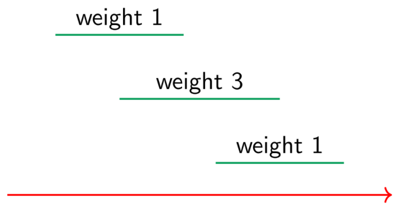

- Search for another greedy strategy that works ...
- ... or look for an inclusive solution that is "obviously" correct

### Weighted Interval Scheduling

- Order by bookings by starting time, $b_1, b_2, ..., b_n$
- Begin with $b_1$
  - Either $b_1$ is part of the optimal solution, or it is not
  - Include $b_1 \implies$ eliminate conflicting requests in $b_2, ..., b_n$ and solve resulting subproblem
  - Exclude $b_1 \implies$ solve subproblem $b_2,..., b_n$
  - Evaluate both options, choose the maximum
- Inductive solution considers all options
  - For each $b_j$, optimal solution either has $b_j$ or does not
  - For $b_1$, we have explicitly checked both cases
  - If $b_2$ is not in conflict with $b_1$, it will be considered in both subproblems with and without $b_1$
  - If $b_2$ is in conflict with $b_1$, it will be considered in the subproblem where $b_1$ is excluded

### The challenge

- $b_1$ is in conflict with $b_2$, but both are compatible with $b_3, b_4, ..., b_n$
  - Choose $b_1 \implies$ subproblem $b_3, ..., b_n$
  - Exclude $b_1 \implies$ subproblem $b_2, ... b_n$
  - Next stage
    - Choose/exclude $b_2$
    - Both choices result in $b_3, ..., b_n$, same subproblem
- Inductive solution generates same subproblem at different stages
- Naive recursion implementation evaluates each instance of subproblem from scratch
- Can we avoid this wasteful recomputation
- Memoization and Dynamic Programming?

# **Memoization**

### **Evaluating Subproblems**

- Fibonacci numbers
  - $fib(0) = 0$
  - $fib(1) = 1$
  - $fib(n) = fib(n - 1) + fib(n - 2)$

```python
def fib(n):
  if n <= 1:
    value = n
  else:
    value = fib(n - 1) + fib(n - 2)

  return value
```

- Wasteful recomputation
- Computation tree grows exponentially

**Evaluating `fib(5)`**

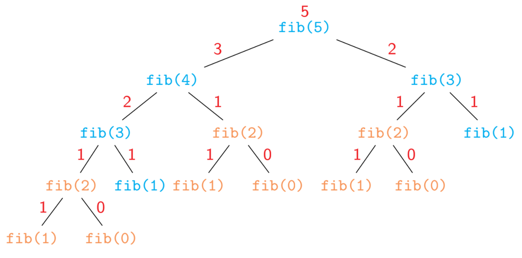

### **Evaluating Subproblems**

- Build a table of values already computed
  - Memory table
- Memoization
  - Check if the value to be computed was already seen before
- Store each newly computed value in a table
- Look up the table before making a recursive call
- Computation tree becomes linear

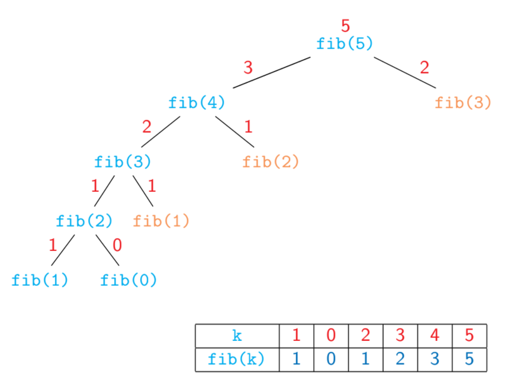

### **Memoizing recursive implementations**

```python
def fib(n):
  if n in fibtable.keys():
    return fibtable[n]

  if n <= 1:
    value = n
  else:
    value = fib(n - 1) + fib(n - 2)

  fibtable[n] = value
  return value
```

**In general**

```python
def f(x, y, z):
  if (x, y, z) in ftable.keys():
    return ftable[(x, y, z)]

  recursively compute values
    from subproblems

  ftable[(x, y, z)] = value
  return value
```

### **Dynamic programming**

- Anticipate the structure of subproblems
  - Derive from inductive definition
  - Dependencies form a DAG
- Solve subproblems in topological order
  - Never need to make a recursive call

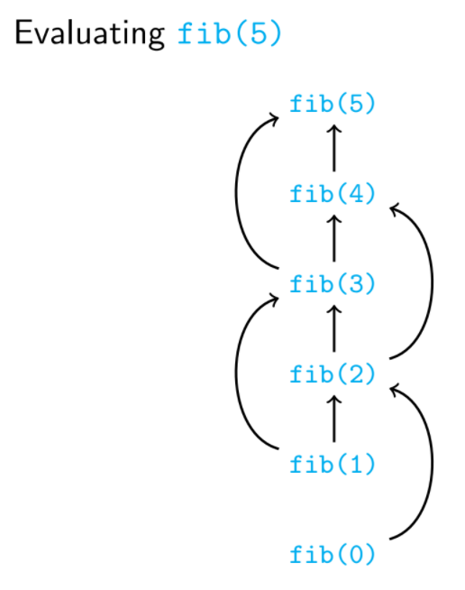

### **Summary**

**Memoization**

- Store subproblem values in a table
- Look up the table before making a recursive call

**Dynamic programming**

- Solve subproblems in a topological order of dependency
  - Dependencies must form a DAG
- Iterative evaluation of subproblems, no recursion

# **Grid Paths**

### Grid Paths

- Rectangular paths of one-way roads
- Can only go up and right
- How many paths form $(0, 0)$ to $(m, n)$?

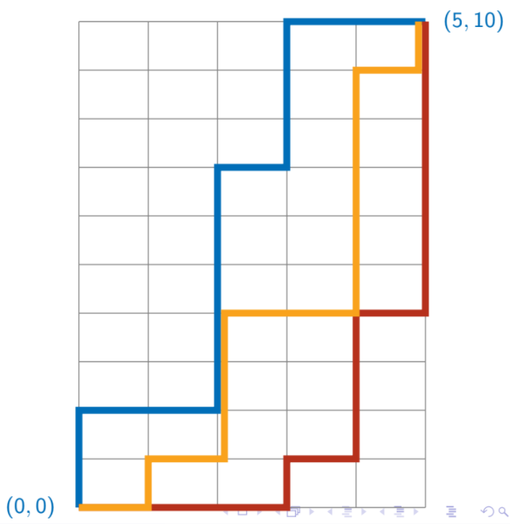

### **Combinatorial solution**

- Every path from $(0, 0)$ to $(5, 10)$ has $15$ segments
  - In general, $m + n$ segments from $(0, 0)$ to $(m, n)$
- Out of $15$, exactly $5$ are right moves, $10$ are up moves
- Fix the position of the $5$ right moves among the $15$ positions overall
  - $C^{15}_{5} = \frac{15!}{10!.5!} = 3003$
  - Same as $C^{15}_{10}$ -- fix the $10$ up moves

### **Holes**

- What if an intersection is blocked?
  - For instance, $(2,4)$
- Need to discard paths passing through $(2,4)$
  - Two of our earlier examples are invalid paths

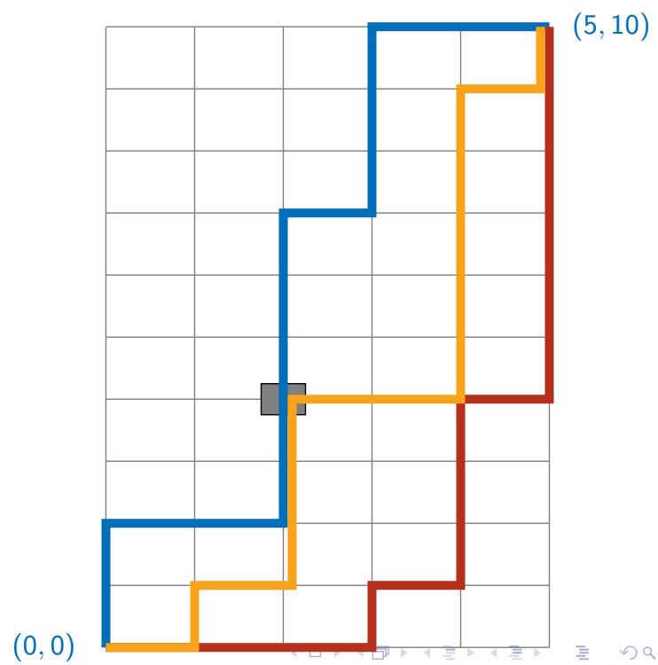

### **Combinatorial solution for holes**

- Discard paths passing through $(2,4)$
- Every path via $(2,4)$ combines a path from $(0,0)$ to $(2,4)$ with a path from $(2,4)$ to $(5,10)$
  - Count these separately
  - $C^{2+4}_{2} = 15$ paths from $(0,0)$ to $(2,4)$
  - $C^{3+6}_{3} = 84$ paths from $(2,4)$ to $(5,10)$
- $15 \times 84 = 1,260$ paths via $(2,4)$
- $3,003 - 1,260 = 1,743$ valid paths avoiding $(2,4)$

### **More holes**

- What if two intersections are blocked?
- Discard paths via $(2,4), (4,4)$
  - Some paths are counted twice
- Add back the paths that pass through both holes
- **Inclusion-exculsion** -- counting is messy

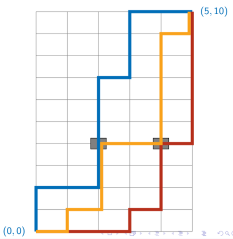

### **Inductive formulation**

- How can a path reach $(i,j)$
  - Move up from $(i, j - 1)$
  - Move right from $(i - 1, j)$
- Each path to these neighbours extends to a unique path to $(i, j)$
- Recurrence for $P(i, j)$, number of paths from $(0,0)$ to $(i, j)$
  - $P(i,j) = P(i-1,j) + P(i,j-1)$
  - $P(0,0)=1$ -- base case
  - $P(i,0)=P(i-1,0)$ -- bottom row
  - $P(0,j)=P(0,j-1)$ -- left column
- $P(i,j) = 0$ if there is a hole at $(i,j)$

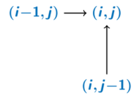

### **Computing $P(i,j)$**

- Naive recursion recomputes same subproblem repeatedly
  - $P(5,10)$ requires $P(4,10), P(5,9)$
  - Both $P(4,10), P(5,9)$ require $P(4,9)$
- Use memoization ...
- ... or find a suitable order to compute the subproblems

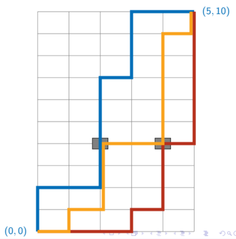

### **Dynamic Programming**

- Identify the DAG structure
- $P(0,0)$ has no dependencies

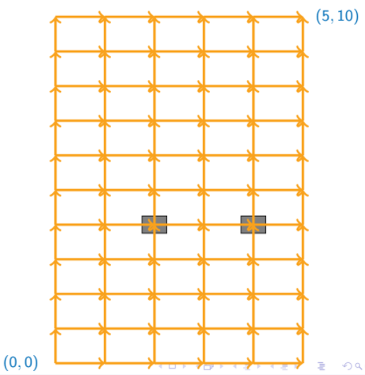

- Start at $(0,0)$
- Fill row by row

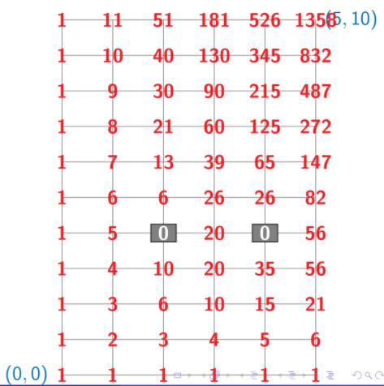

- Fill column by column

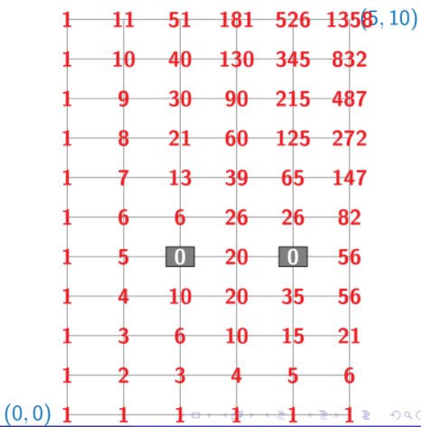

- Fill diagonal by diagonal

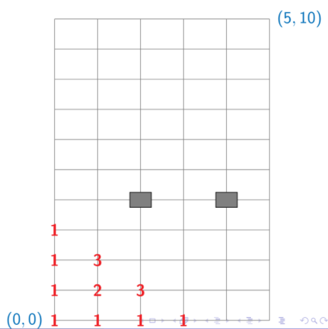

### **Memoization vs Dynamic Programming**

- Barrier of holes just inside the border
- Memoization never explores the shaded region
- Memo table has $O(m+n)$ entries
- Dynamic programming blindly fills all $mn$ cells of the table
- Tradeoff between recursion and iteration
  - "Wasteful" dynamic programming still better in general

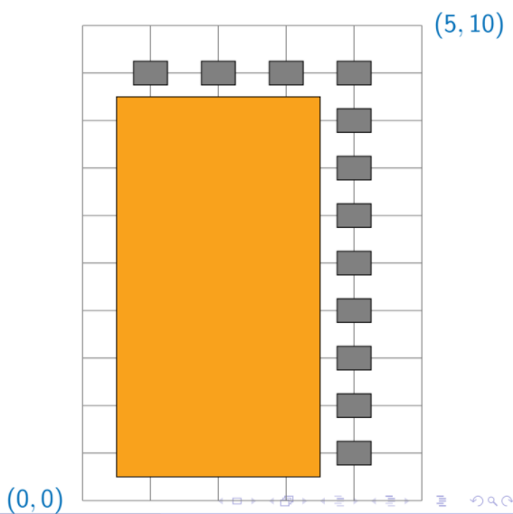

# **Common Subwords and Sequences**

### **Brute force**

- $u = a_0a_1...a_{m-1}$
- $v = b_0b_1...b_{n-1}$
- Find the largest $k$ such that for some positions $i$ and $j$, $a_ia_{i+1}a_{i+k-1} = b_jb_{j+1}b_{j+k-1}$
- Try every pair of starting positions $i$ in $u$, $j$ in $v$
  - Match $(a_i, b_j), (a_{i+1}, b_{j+1})...$ as far as possible
  - Keep track of longest match
- Assuming $m \gt n$, this is $O(mn^2)$
  - $mn$ pairs of starting positions
  - From each starting position, scan could be $O(n)$

### **Inductive structure**

- $u = a_0a_1...a_{m-1}$
- $v = b_0b_1...b_{n-1}$
- Find the largest $k$ such that for some positions $i$ and $j$, $a_ia_{i+1}a_{i+k-1} = b_jb_{j+1}b_{j+k-1}$
- $LCW(i,j)$ - length of the longest common subword in $a_ia_{i+1}...a_{m-1}, b_jb_{j+1}...b_{n-1}$
  - If $a_i \neq b_j$, $LCW(i,j) = 0$
  - If $a_i = b_j$, $LCW(i,j) = 1 + LCW(i+1, j+1)$
  - Base case: $LCW(m, n) = 0$
  - In general, $LCW(i, n) = 0$ for all $0 \leq i \leq m$
  - In general, $LCW(m, j) = 0$ for all $0 \leq j \leq n$

### **Subproblem dependency**

- Subproblems are $LCW(i, j)$, for $0 \leq i \leq m, 0 \leq j \leq n$
- Table of $(m+1).(n+1)$ values
- $LCW(i,j)$ depends on $LCW(i+1, j+1)$
- Start at the bottom right and fill row by row or column by column

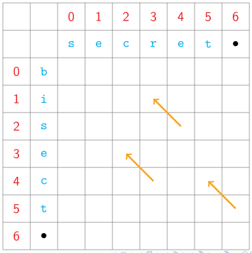

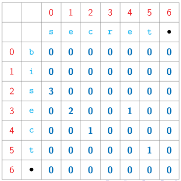

**Reading off the solution**

- Find entry $(i,j)$ with the largest $LCW$ value
- Read off the actual subword diagonally

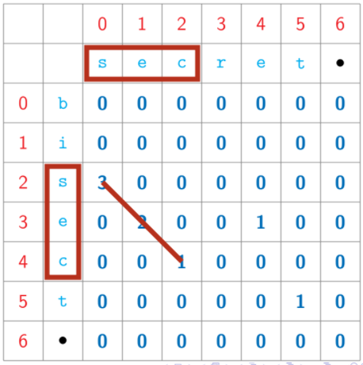

### **Implementation**

```python
def LCW(u, v):
  import numpy as np
  (m, n) = (len(u), len(v))
  lcw = np.zeros((m + 1, n + 1))
  max_lcw = 0

  for c in range(n - 1, -1, -1):
    for r in range(m - 1, -1, -1):
      if u[r] == v[c]:
        lcw[r, c] = 1 + lcw[r + 1, c + 1]
      else:
        lcw[r, c] = 0

      if lcw[r, c] > max_lcw:
        max_lcw = lcw[r, c]

  return max_lcw
```

**Complexity**

- Recall that the brute force was $O(mn^2)$
- Inductive solution is $O(mn)$, using dynamic programming or memoization
  - Fill a table of size $O(mn)$
  - Each table entry takes constant time to compute

### **Longest Common Subsequence**

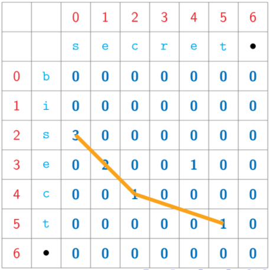

### **Applications**

- Analyzing genes
  - DNA is a long string over `A, T, G, C`
  - Two species are similar if their DNA has long common subsequences
- `diff` command in Unix/Linux
  - Compares text files
  - Find the longest matching subsequence of lines
  - Each line of text is a "character"

### **Subproblem dependency**

- Subproblems are $LCS(i, j)$, for $0 \leq i \leq m, 0 \leq j \leq n$
- Table of $(m + 1).(n + 1)$ values
- $LCS(i, j)$ depends on $LCS(i + 1, j + 1), LCS(i, j + 1), LCS(i + 1, j)$

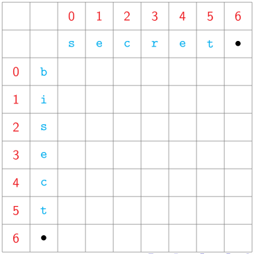

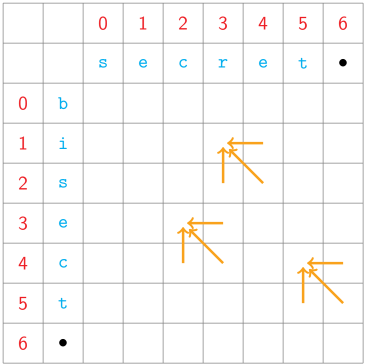

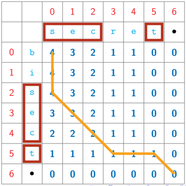

- No dependency for $LCS(m,n)$ - start at bottom right and fill by row, column or diagonal

**Reading off the solution**

- Trace back the path by which each entry was filled
- Each diagonal step is an element of $LCS$

```python
def LCS(u, v):
  import numpy as np
  (m, n) = (len(u), len(v))
  lcs = np.zeros((m + 1, n + 1))

  for c in range(n - 1, -1, -1):
    for r in range(m - 1, -1, -1):
      if u[r] == v[c]:
        lcs[r, c] = 1 + lcs[r + 1, c + 1]
      else:
        lcs[r, c] = max(lcs[r + 1, c], lcs[r, c + 1])

  return lcs[0,0]
```

**Complexity**

- Again $O(mn)$, using dynamic programming or memoization
  - Fill a table of size $O(mn)$
  - Each table entry takes constant time to compute

# **Edit Distance**

### **Document similarity**

- "The students were able to appreciate the concept optimal substructure property and its use in designing algorithms"
- "The lecture taught the students to appreciate how the concept of optimal substructures can be used in designing algorithms"
- Edit operations to transform documents
  - Insert a character
  - Delete a character
  - Substitute one character by another
- "The lecture taught the students were able to appreciate how the concept of optimal substructures property cand itbse used in designing algorithms"
- insert, delete, substitute

**Edit distance**

- Minimum number of edit operations needed
- In our example, 24 characters inserted, 18 deleted, 2 substituted
- Edit distance is at most 44

### **Edit distance**

- Minimum number of editing operations needed to transform one document to the other
  - Insert a character
  - Delete a character
  - Substitute one character by another
- Also called Levenshtein distance
  - Vladimir Levenshtein, 1965
- Applications
  - Suggestions for spelling correction
  - Genetic similarity of species

**Edit distance and LCS**

- Longest common subsequence of $u, v$
  - Minimum number of deletes needed to make them equal
- Deleting a letter from $u$ is equivalent to inserting it in $v$
  - `bisect, secret` - LCS is `sect`
  - Delete `b, i` in `bisect` and `r, e` in `secret`
  - Delete `b, i` and then insert `r, e` in `bisect`
- LCS equivalent to edit distance without substitution

### **Inductive structure for edit distance**

- $u = a_0a_1...a_{m-1}$
- $v = b_0b_1...b_{n-1}$
- Recall LCS
- If $a_i=b_j$, $LCS(i,j) = 1 + LCS(i+1,j+1)$
- if $a_i \neq b_j$, $LCS(i,j) = max(LCS(i,j+1), LCS(i+1,j))$
- Edit distance - aim is to transform $u$ to $v$
- If $a_i=b_j$, nothing to be done
- If $a_i \neq b_j$, best among
  - Substitute $a_i$ by $b_j$
  - Delete $a_i$
  - Insert $b_j$ before $a_i$
- $ED(i, j)$ - edit distance for $a_ia_{i+1}...a_{m-1}, b_jb_{j+1}...b_{n-1}$
- If $a_i = b_j$, $ED(i, j) = ED(i+1,j+1)$
- If $a_i \neq b_j$, $ED(i, j) = 1 + min(ED(i+1,j+1), ED(i+1,j), ED(i,j+1))$
- Base case
  - $ED(m,n)=0$
  - $ED(i,n)=m-i$ for all $0 \leq i \leq m$, Delete $a_ia_{i+1}...a_{m-1}$ fro $u$
  - $ED(m,j)=n-j$ for all $0 \leq j \leq n$, Insert $b_jb_{j+1}...b_{n-1}$ into $u$

### **Subproblem dependency**

- Subproblems are $ED(i, j),$ for $0 \leq i \leq m, 0 \leq j \leq n$
- Table of $(m+1).(n+1)$ values

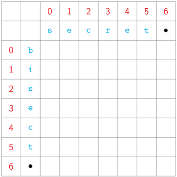

- Like LCS, $ED(i,j)$ depends on $ED(i+1,j+1), ED(i,j+1), ED(i+1,j)$

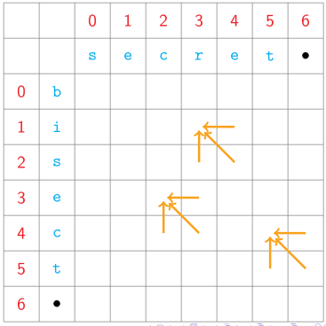

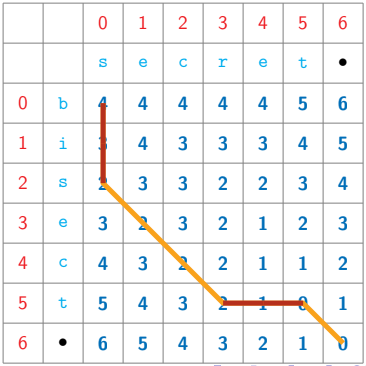

- No dependency for $ED(m,n)$ - start at bottom right and fill by row, column or diagonal

**Reading off the solution**

- Transform `bisect` to `secret`
- Delete `b`, Delete `i`, Insert `r`, Insert `e`

```python
def ED(u, v):
  import numpy as np
  (m, n) = (len(u), len(v))
  ed = np.zeros((m + 1, n + 1))

  for i in range(m - 1, -1, -1):
    ed[i, n] = m - i
  for j in range(n - 1, -1, -1):
    ed[m, j] = n - j

  for j in range(n - 1, -1, -1):
    for i in range(m - 1, -1, -1):
      if u[i] == v[j]:
        ed[i, j] = ed[i + 1, j + 1]
      else:
        ed[i, j] = 1 + min(ed[i + 1, j + 1], ed[i, j + 1], ed[i + 1, j])
```

**Complexity**

- Again, $O(mn)$, using dynamic programming or memoization
  - Fill a table of size $O(mn)$
  - Each table entry takes constant time to compute

# **Matrix Multiplication**

### **Multiplying matrices**

- Multiple matrices $A, B$
  - $AB[i, j] = \Sigma^{n-1}_{k=0}A[i, k]B[k, j]$
- Dimensions must be compatible
  - $A: m \times n, B: n \times p$
  - $AB: m \times p$
- Computing each entry in $AB$ is $O(n)$
- Overall, computing $AB$ is $O(mnp)$
- Matrix multiplication is associative
  - $ABC = (AB)C = A(BC)$
  - Brackting does not change answer
  - ... but can affect the complexity
- Let $A:1 \times 100, B: 100 \times 1, C: 1 \times 100$
- Computing $A(BC)$
  - $BC: 100 \times 100$, takes $100.1.100 = 10000$ steps to compute
  - $A(BC): 1 \times 100$, takes $1.100.100 = 10000$ steps to compute
- Computing $(AB)C$
  - $AB: 1 \times 1$, takes $1.100.1 = 100$ steps to compute
  - $(AB)C: 1 \times 100$, takes $1.1.100 = 100$ steps to compute
- $20000$ steps vs $200$ steps
- Given $n$ matrices $M_0: r_0 \times c_0$, $M_1: r_1 \times c_1, ..., M_{n-1}: r_{n-1} \times c_{n-1}$
  - Dimensions match: $r_j = c_{j-1}, 0 \lt j \lt n$
  - Product $M_0.M_1...M_{n-1}$ can be computed
- Find the optimal order to compute the product
  - Multiple 2 matrices at a time
  - Bracket the expression optimally

### **Inductive Structure**

- Final step combines two subproducts $(M_0.M_1...M_{k-1}).(M_k.M_{k+1}...M_{n-1})$ for some $0 \lt k \lt n$
- First factor is $r_0 \times c_{k-1}$, second is $r_k \times c_{n-1}$, where $r_k = c_{k-1}$
- Let $C(0, n-1)$ denote the overall cost
- Final multiplication is $O(r_0r_kc_{n-1})$
- Inductively, costs of factors are $C(0, k-1)$ and $C(k, n-1)$
- $C(0,n-1) = C(0,k-1)+C(k,n-1)+r_0r_kc_{n-1}$
- Which $k$ should we choose?
  - Try all and choose the minimum!
- Subproblems?
  - $M_0.M_1...M_{k-1}$ would decompose as $(M_0...M_{j-1}).(M_j...M_{k-1})$
  - Generic subproblem is $M_j.M_{j+1}...M_k$
- $C(j,k) = min_{j \lt l \leq k}[C(j,l-1)+C(l,k)+r_jr_lc_k]$
- Base case: $C(j,j)=0$ for $0 \leq j \lt n$

### **Subproblem dependency**

- Compute $C(i,j),0 \leq i,j \lt n$
  - Only for $i \leq j$
  - Entries above main diagonal

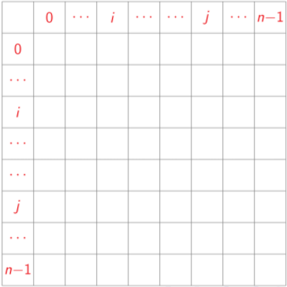

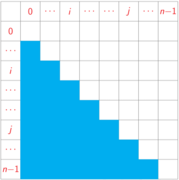

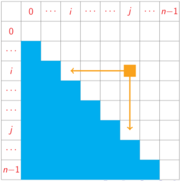

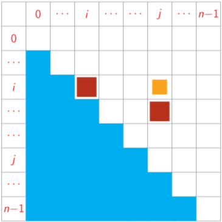

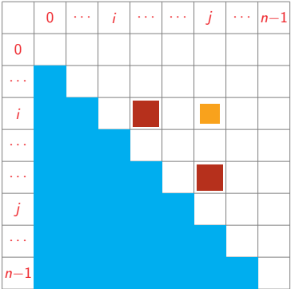

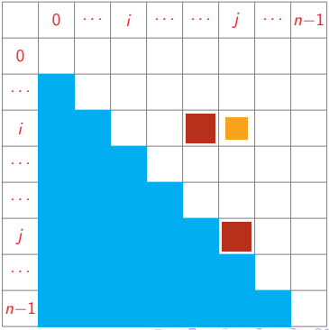

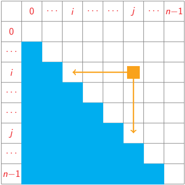

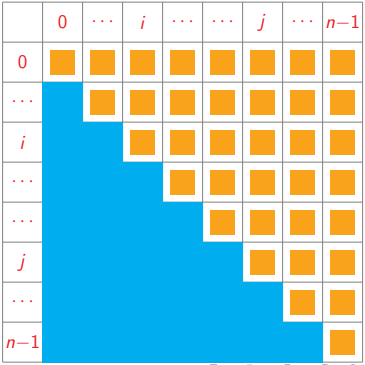

- $C(i,j)$ depends on $C(i,k-1),C(k,j)$ for every $i \lt k \leq j$
  - $O(n)$ dependencies per entry, unlike LCW, LCS and ED
- Diagonal entries are base case
- Fill matrix by diagonal, from main diagonal

### **Implementation**

```python
def C(dim):
  # dim: dimension matrix,
  #      entries are pairs (r_i, c_i)
  import numpy as np
  n = dim.shape[0]
  C = np.zeros((n, n))

  for i in range(n):
    C[i, i] = 0

  for diff in range(1, n):
    j = i + diff
    C[i, j] = C[i, i] + C[i + 1, j] + dim[i][0] * dim[i + 1][0] * dim[j][1]

    for k in range(i + 1, j + 1):
      C[i, j] = min(C[i, j], C[i, k - 1] + C[k, j] + dim[i][0] * dim[k][0] * dim[j][1])

  return C[0, n - 1]
```

**Complexity**

- We have to fill a table of size $O(n^2)$
- Filling each entry takes $O(n)$
- Overall, $O(n^3)$